# two-state modeling

2026-04-26

This R markdown file contains code to run two-state modeling on the combinatorial SCR library tested in the first SCR Macrophage manuscript. I recommend running this as code chunks in Rstudio.

First: Define 2 paths: 1. Directory where you have downloaded `phago_suma_combined.Rds` 2. Directory where you want to save plots from running this script. If using Rstudio, the plots will be printed to in-line. You can comment out the ggsave lines if you do not want to save these plots.

```r
data_folder <- "/Users/jodielunger/OneDrive - Stanford/Code/combo_lib_modeling/"
plot_folder <- "/Users/jodielunger/OneDrive - Stanford/Code/combo_lib_modeling/"
```

# Step 1 - Load Required Packages

```r
library(dplyr)
```

```r
library(ggplot2)
library(tidyr)
library(purrr)
library(stringr)
library(broom)
library(forcats)
library(tibble)
library(rsample)
library(ggrepel)
library(ggh4x)
```

# Step 2 - Load Data

The measurements used are: - MFI values as raw flow cytometry readouts from surface marker analysis - Phagocytosis index: Raw “red total intensity” readout from the Incucyte as a proxy for phagocytosis of pHrodo-labeled E. coli

```r
phenotype_data <- readRDS(file.path(data_folder, "phago_suma_combined.Rds"))
head(phenotype_data)
```

```
## # A tibble: 6 × 20
##   plate well  sample_name sample_type  phagocytosis_index transduction_status
##   <dbl> <chr> <chr>       <chr>                     <dbl> <chr>
## 1     1 A1    S6-S7       Double motif           16742040 T
## 2     1 A10   S7-S5-S5    Triple motif           13382420 T
## 3     1 A11   S3-S3       Double motif           26772500 T
## 4     1 A3    S7-S1       Double motif           14249200 T
## 5     1 A4    S6-S9       Double motif           17460320 T
## 6     1 A5    S2-S2       Double motif           30656160 T
## # ℹ 14 more variables: treatment <chr>, reps <dbl>, motif_ID_1 <chr>,
## #   motif_ID_2 <chr>, motif_ID_3 <chr>, motif_number <fct>, CD163_MFI <int>,
## #   CD80_MFI <int>, CD206_MFI <int>, CD40_MFI <int>, PDL1_MFI <int>,
## #   percent_GFP <dbl>, motif_list <list>, motif_count <int>
```

Filter data to only include samples which were transduced with an SCR

```r
synth_df <- subset(phenotype_data, transduction_status == "T")
```

# Step 3 - Create definitions for analysis

```r
# Define phenotype columns present in your data
phenotype_cols   <- c("CD163_MFI","CD80_MFI","CD206_MFI","CD40_MFI","PDL1_MFI", "phagocytosis_index")
motif_cols <- c("motif_ID_1", "motif_ID_2", "motif_ID_3")

# Benchmarks (keep in clustering)
bench_samples <- c("GM-CSF","IFNγ","IFNγ + LPS","IL-10","IL-4","UT","empty")
```

# Step 4 - Count how many of each motif is in each SCR

```r
# Add a unique row_id to preserve sample identity across reshaping
# operations (pivot_longer / pivot_wider).
orig_df <- synth_df %>%
  mutate(row_id = row_number())

# ---- Convert motif columns to long format ----
# This creates one row per (sample, motif copy), allowing motifs
# to be counted if they appear multiple times within a sample.
motifs_long <- orig_df %>%
  pivot_longer(
    cols = all_of(motif_cols),   # melt motif_ID_1/2/3 into a single column
    names_to = "slot",           # original position (not used downstream)
    values_to = "motif"          # motif identity (e.g., "S1", "S2")
  ) %>%
  # Remove empty motif entries
  # (samples with fewer than 3 motifs will have "" in places where the 1st, 2nd, or 3rd motif would go)
  filter(!is.na(motif), motif != "") %>%
  # Group by sample and motif to count how many times
  # each motif appears within each construct
  group_by(row_id, motif) %>%
  summarise(
    cnt = n(),                   # number of copies of this motif in the sample
    .groups = "drop"
  )

# ---- Pivot to wide format to create a motif count matrix ----
# Each motif becomes its own column
# and each cell contains the copy number of that motif in the sample.
motifs_wide <- motifs_long %>%
  pivot_wider(
    names_from  = motif,         # motif identities become column names
    values_from = cnt,           # fill cells with motif copy counts
    values_fill = 0              # motifs not present get a count of 0
  )

# This is an important line that ensures motifs all get labeled as having zero copies in SCR0
motif_count_cols <- setdiff(names(motifs_wide), "row_id") # list the motif columns so that NAs are replaced as 0 ONLY in these columns!!

# ---- Join motif counts back to the original dataframe ----
# This produces the final modeling dataframe, where:
#   - original sample metadata and phenotypes are preserved
#   - each motif column encodes copy number (0, 1, 2, ...)
synth_df <- orig_df %>%
  left_join(motifs_wide, by = "row_id") %>%
  mutate(across(all_of(motif_count_cols), ~ tidyr::replace_na(.x, 0))) %>%
  select(-row_id) # remove temporary identifier
```

# Step 5 - Summarize replicates

Create version of synth_df with averaged replicates

```r
# ------------------------------------------------------------------------------
# Aggregate Replicates and Calculate Standard Errors
# ------------------------------------------------------------------------------
synth_df_aggregated <- synth_df %>%
  group_by(sample_name) %>%
  summarise(
    # ------------------------------------------------------------
    # Keep motif counts as columns (identical across replicates)
    # ------------------------------------------------------------
    across(all_of(c("S1", "S2", "S3", "S4", "S5", "S6", "S7", "S8", "S9")), dplyr::first),


    # ------------------------------------------------------------
    # Raw measurement columns (from your phenotype_cols vector): mean, SE, and n
    # -> produces columns like CD40_MFI_mean, CD40_MFI_se, CD40_MFI_n
    # ------------------------------------------------------------
    across(
      all_of(phenotype_cols),
      list(
        mean = ~ mean(., na.rm = TRUE),
        se   = ~ sd(., na.rm = TRUE) / sqrt(sum(!is.na(.))),
        n    = ~ sum(!is.na(.))
      ),
      .names = "{.col}_{.fn}"
    ),
    .groups = "drop"
  )
```

# Step 6 - Plot phenotype distributions and store extreme values

```r
# ------------------------------------------------------------------------------
# Determine State(low) and State(high) from MFI and phagocytosis data (all phenotype data)
# ------------------------------------------------------------------------------

# Assign mean columns
phenotype_mean_cols <- synth_df_aggregated %>%
  select(ends_with("_mean")) %>%
  colnames()


# Create dataframe for phenotype data
phenotype_data <- synth_df_aggregated %>%
  select(sample_name, S1:S9, ends_with("_mean"))

# Helper: estimate two-state expression bounds for one phenotype column
# State_low  = lowest observed value
# State_high = highest observed value

# Function to plot distributions of each phenotype and store the extreme (min and max) values
estimate_two_state_extremes <- function(df, pheno_col, k = 1, make_plot = TRUE) {
  stopifnot(pheno_col %in% names(df))

  d <- df %>%
    select(sample_name, S1:S9, all_of(pheno_col)) %>%
    drop_na(all_of(pheno_col))

  if (nrow(d) == 0) {
    return(list(
      results = tibble(
        phenotype = pheno_col,
        n_samples = 0L,
        State_low = NA_real_,
        State_high = NA_real_
      ),
      plot = NULL,
      sorted = tibble()
    ))
  }

  # Sort like your phago code
  sorted <- d %>%
    arrange(.data[[pheno_col]]) %>%
    select(sample_name, !!pheno_col)

  k_use <- min(k, nrow(sorted))

  low_samples  <- head(sorted$sample_name, k_use)
  high_samples <- tail(sorted$sample_name, k_use)

  State_low  <- mean(head(sorted[[pheno_col]], k_use), na.rm = TRUE)
  State_high <- mean(tail(sorted[[pheno_col]], k_use), na.rm = TRUE)

  # Mark which samples were used
  d_plot <- d %>%
    mutate(
      bound_group = dplyr::case_when(
        sample_name %in% low_samples  ~ paste0("Bottom ", k_use, " (State_low)"),
        sample_name %in% high_samples ~ paste0("Top ", k_use, " (State_high)"),
        TRUE                          ~ "Other"
      ),
      bound_group = factor(
        bound_group,
        levels = c(paste0("Bottom ", k_use, " (State_low)"),
                   paste0("Top ", k_use, " (State_high)"),
                   "Other")
      )
    )

  p <- NULL
  if (isTRUE(make_plot)) {
    p <- ggplot(d_plot, aes(x = .data[[pheno_col]])) +
      geom_histogram(bins = 30, fill = "grey85", color = "grey30", linewidth = 0.3) +
      # Color ONLY the selected samples on the x-axis
      geom_rug(
        data = d_plot %>% filter(bound_group != "Other"),
        aes(color = bound_group),
        sides = "b",
        alpha = 0.95,
        linewidth = 1.0
      ) +
      # Dotted lines at the averages used for bounds
      geom_vline(xintercept = State_low,  linetype = "dotted", linewidth = 0.8) +
      geom_vline(xintercept = State_high, linetype = "dotted", linewidth = 0.8) +
      labs(
        title = paste0("Phenotype Distribution: ", pheno_col),
        subtitle = paste0(
          "Colored ticks = samples used for bounds; dotted lines = State_low (",
          round(State_low, 2), ") and State_high (", round(State_high, 2), ")"
        ),
        x = pheno_col,
        y = "Count",
        color = "Used for bounds"
      ) +
      theme_classic()
  }

  list(
    results = tibble(
      phenotype = pheno_col,
      n_samples = nrow(d),
      State_low = State_low,
      State_high = State_high
    ),
    plot = p,
    sorted = sorted
  )
}

# Run function across all phenotype_mean columns
phenotype_extremes_list <- purrr::map(
  phenotype_mean_cols,
  ~ estimate_two_state_extremes(
    df = phenotype_data,
    pheno_col = .x,
    k = 1,
    make_plot = TRUE
  )
)

# Tidy summary table
phenotype_extremes_tbl <- purrr::map_dfr(phenotype_extremes_list, "results")
print(phenotype_extremes_tbl)
```

```
## # A tibble: 6 × 4
##   phenotype               n_samples State_low State_high
##   <chr>                       <int>     <dbl>      <dbl>
## 1 CD163_MFI_mean                131     5013.     36821.
## 2 CD80_MFI_mean                 131      919.      4178.
## 3 CD206_MFI_mean                131     3566.     32566.
## 4 CD40_MFI_mean                 131     7088.     40687.
## 5 PDL1_MFI_mean                 131     1632.     20452.
## 6 phagocytosis_index_mean       131  7826630.  29250673.
```

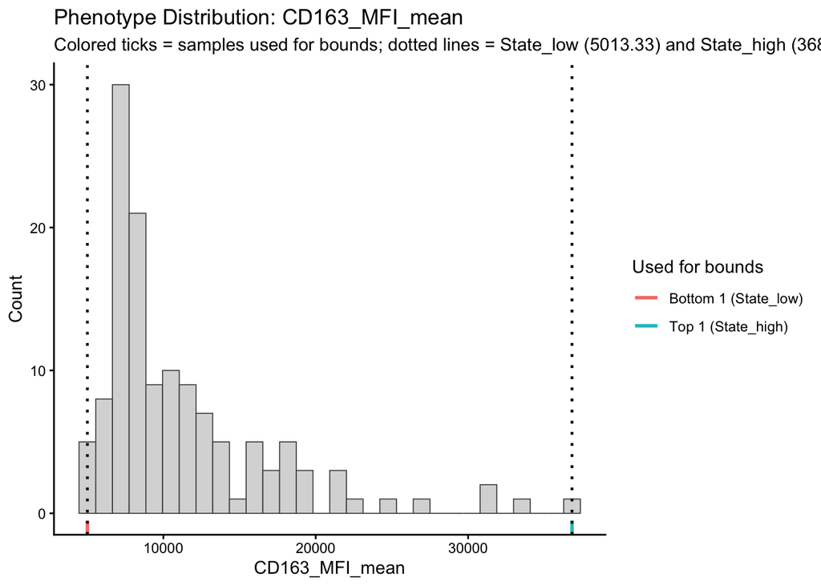

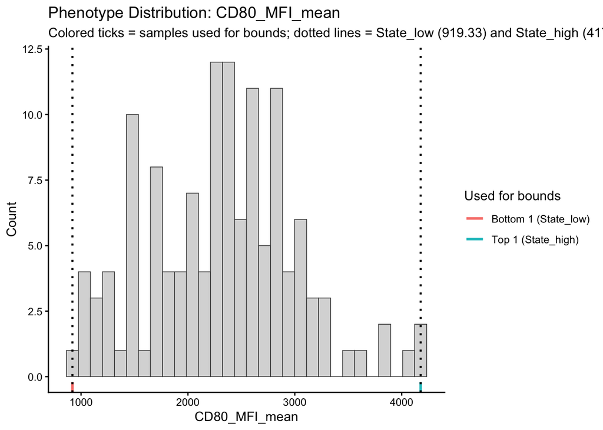

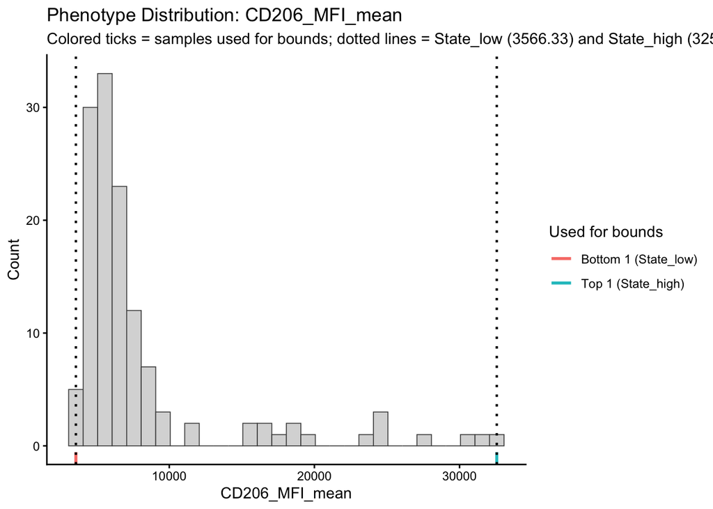

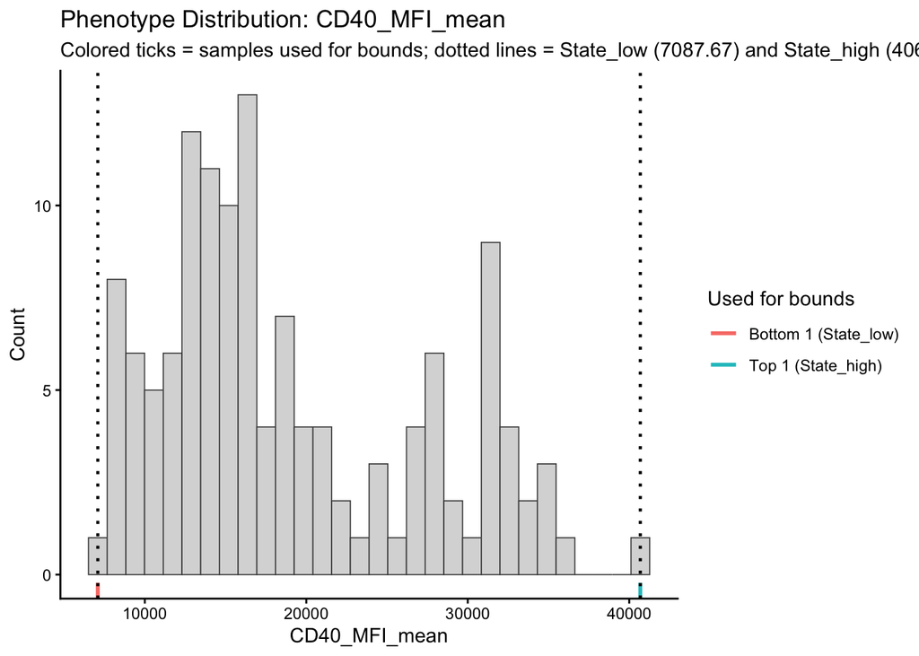

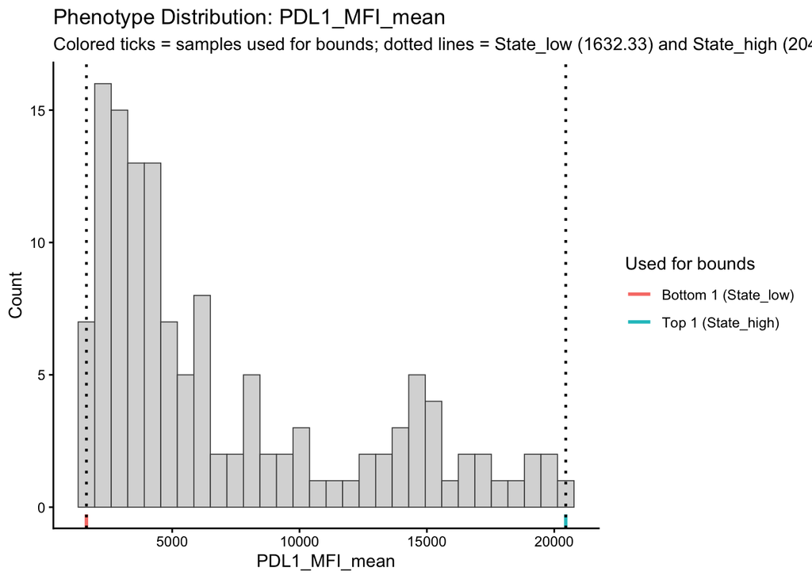

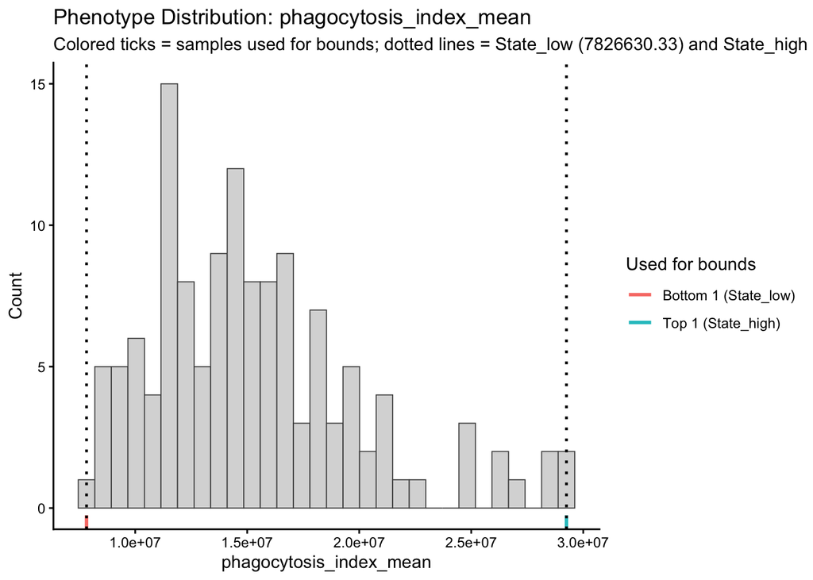

```r
# Display all histograms in RMarkdown
purrr::walk(phenotype_extremes_list, ~ if (!is.null(.x$plot)) print(.x$plot))
```

# Step 7 - Fit the two-state model

The two-state model assumes cells exist as a population of cells in two states, where the fraction of cells in each state determines the resulting phenotype measurement for each phenotype.

$$\text{Phenotype}_{\text{observed}} = \text{State}_{low} \cdot (1 -
f_{high}) + \text{State}_{high} \cdot f_{high}$$

Where:

The fraction of cells in the high state is determined by the equilibrium constant $K$:

$$f_{high} = \frac{K}{1 + K}$$

where the equilibrium constant relates to a change in energy between the low and high phenotype state:

$$K = e^{-\Delta E}$$

Substituting this into the fraction equation:

$$f_{high} = \frac{e^{-\Delta E}}{1 + e^{-\Delta E}} = \frac{1}{1 +
e^{\Delta E}}$$

Combining these relationships, the model becomes:

$$\text{Phenotype}_{\text{observed}} = \text{State}_{low} \cdot \left(1 -
\frac{1}{1 + e^{\Delta E}}\right) + \text{State}_{high} \cdot \frac{1}{1
+ e^{\Delta E}}$$

where $\Delta E$ follows the same additive motif model as for the surface markers:

$$\Delta E = \Delta E_i + \Delta E_{S1} \cdot n_{S1} + \Delta E_{S2} \cdot
n_{S2} + ... + \Delta E_{S9} \cdot n_{S9}$$
where $\Delta E_{i}$ is the intrinsic $\Delta E$ value when there are no motifs present in the SCR.

Create a base dataset for model fitting

```r
# Assign motif_cols to be S1:S9
motif_cols    <- paste0("S", 1:9)

# Base dataframe used for fitting: motifs + all mean phenotypes
base_fit_df <- synth_df_aggregated %>%
  select(sample_name, all_of(motif_cols), all_of(phenotype_mean_cols)) %>%
  drop_na(all_of(motif_cols))
```

Define helper functions

```r
# Helper functions used by fit_one_phenotype_de_all_plus_cvsd:
#
#   safe_cor(x, y)
#     Pearson correlation that returns NA instead of crashing when there are
#     too few points or zero-variance inputs.
#
#   rmse(x, y)
#     Root mean squared error between two numeric vectors.
#
#   phenotype_to_de(phenotype, State_low, State_high, eps)
#     Converts a raw phenotype value to ΔE using the two-state model.
#     First computes fractional occupancy f = (phenotype - State_low) /
#     (State_high - State_low), clips f to [eps, 1-eps], then returns
#     ΔE = log((1-f)/f). Returns NA for missing or degenerate inputs.
#
#   de_to_phenotype(dE, State_low, State_high)
#     Inverse of phenotype_to_de. Converts a predicted ΔE back to predicted
#     phenotype: f = 1/(1+exp(ΔE)), phenotype = State_low*(1-f) + State_high*f.

# Correlation that won't crash if there are too few points or zero variance
safe_cor <- function(x, y) {
  if (length(x) < 3) return(NA_real_)
  if (sd(x, na.rm = TRUE) == 0 || sd(y, na.rm = TRUE) == 0) return(NA_real_)
  cor(x, y, use = "complete.obs")
}

# Root mean squared error
rmse <- function(x, y) sqrt(mean((x - y)^2, na.rm = TRUE))

# Convert phenotype -> ΔE using two-state mapping:
#   f   = (phenotype - State_low) / (State_high - State_low)
#   ΔE  = log((1-f)/f)
# eps clips f away from 0 and 1 so ΔE doesn't become +/- infinity.
phenotype_to_de <- function(phenotype, State_low, State_high, eps = 1e-6) {
  denom <- State_high - State_low
  ifelse(
    is.na(phenotype) | is.na(State_low) | is.na(State_high) | denom == 0,
    NA_real_,
    {
      f <- (phenotype - State_low) / denom
      f <- pmin(pmax(f, eps), 1 - eps)
      log((1 - f) / f)
    }
  )
}

# Convert predicted ΔE back to predicted phenotype:
#   f = 1/(1+exp(ΔE))
#   phenotype_pred = State_low*(1-f) + State_high*f
de_to_phenotype <- function(dE, State_low, State_high) {
  f <- 1 / (1 + exp(dE))
  State_low * (1 - f) + State_high * f
}
```

Define a function to fit SCR motif library data to a single phenotype

```r
# fit_one_phenotype_de_all_plus_cvsd fits a linear model in ΔE space for one
# phenotype and returns three output tables: coefficients, per-sample
# predictions, and fit quality metrics.
#
# Steps:
#   1. Look up bounds (State_low, State_high) for this phenotype from
#      phenotype_extremes_tbl. These define the dynamic range of the two-state
#      model and are required for the ΔE transformation.
#
#   2. Build the fitting dataset from base_fit_df. Drops samples missing the
#      phenotype value and transforms each observed phenotype to ΔE, storing
#      intermediate f values for the output table.
#
#   3. Fit a linear model on the full dataset: ΔE ~ S1 + S2 + ... + S9.
#      All expected terms are kept in the output even if dropped by lm (as NA).
#
#   4. Run k-fold cross-validation on training splits to estimate how stable
#      each coefficient is across data subsets. Reports CV-SD (standard
#      deviation of each coefficient across folds, not divided by sqrt(k)).
#
#   5. Predict ΔE for all samples using the full-data coefficients, then
#      back-transform to phenotype space using de_to_phenotype(). Assembles
#      the per-sample prediction table.
#
#   6. Compute fit quality metrics in both ΔE and phenotype space using
#      safe_cor() and rmse(). Also computes residual sigma in ΔE space.

fit_one_phenotype_de_all_plus_cvsd <- function(phenotype_mean_col,
                                               n_folds = 10,
                                               eps     = 1e-6,
                                               seed    = 123) {

  expected_terms <- c("(Intercept)", motif_cols)

  # ---- Step 1: Look up bounds for this phenotype ----
  ext        <- phenotype_extremes_tbl %>% filter(.data$phenotype == phenotype_mean_col) %>% slice(1)
  State_low  <- ext$State_low
  State_high <- ext$State_high

  # ---- Step 2: Build dataset and transform observed phenotype to ΔE ----
  # Uses phenotype_to_de() logic inline to also retain f_obs and f_obs_clipped
  d <- base_fit_df %>%
    select(sample_name, all_of(motif_cols), all_of(phenotype_mean_col)) %>%
    rename(phenotype_obs = all_of(phenotype_mean_col)) %>%
    drop_na(phenotype_obs) %>%
    mutate(
      f_obs         = (phenotype_obs - State_low) / (State_high - State_low),
      f_obs_clipped = pmin(pmax(f_obs, eps), 1 - eps),
      dE_obs        = log((1 - f_obs_clipped) / f_obs_clipped)
    ) %>%
    drop_na(dE_obs)

  cat(sprintf(
    "\nΔE-LM for %s | State_low=%.3f, State_high=%.3f | N=%d, folds=%d\n",
    phenotype_mean_col, State_low, State_high, nrow(d), n_folds
  ))

  fml <- as.formula(paste("dE_obs ~", paste(motif_cols, collapse = " + ")))

  # ---- Step 3: Fit linear model on full dataset ----
  fit_all <- try(lm(fml, data = d), silent = TRUE)
  if (inherits(fit_all, "try-error")) {
    return(list(
      phenotype   = phenotype_mean_col,
      coef_tbl    = tibble(),
      pred_tbl    = tibble(),
      quality_tbl = tibble(
        phenotype  = phenotype_mean_col,
        status     = "model fit failed",
        n_samples  = nrow(d),
        State_low  = State_low,
        State_high = State_high
      )
    ))
  }

  coefs_all <- broom::tidy(fit_all) %>%
    select(term, estimate) %>%
    right_join(tibble(term = expected_terms), by = "term") %>%
    arrange(match(term, expected_terms))

  # ---- Step 4: k-fold CV to estimate coefficient stability (CV-SD) and held-out R² ----
  set.seed(seed)
  folds <- vfold_cv(d, v = n_folds)

  fold_results <- map(folds$splits, function(split) {
    train <- analysis(split)
    test  <- assessment(split)
    fit   <- try(lm(fml, data = train), silent = TRUE)
    if (inherits(fit, "try-error")) {
      return(list(
        coefs = tibble(term = expected_terms, estimate = NA_real_),
        oof   = tibble(observed_dE = test$dE_obs, predicted_dE = NA_real_)
      ))
    }
    list(
      coefs = broom::tidy(fit) %>%
        select(term, estimate) %>%
        right_join(tibble(term = expected_terms), by = "term"),
      oof = tibble(
        observed_dE        = test$dE_obs,
        predicted_dE       = predict(fit, newdata = test),
        observed_phenotype = test$phenotype_obs
      )
    )
  })

  # Coefficient stability: SD of each coefficient across folds
  fold_coefs <- map_dfr(fold_results, "coefs", .id = "fold")
  cv_sd <- fold_coefs %>%
    group_by(term) %>%
    summarise(
      std.dev         = sd(estimate, na.rm = TRUE),
      n_folds_success = sum(!is.na(estimate)),
      .groups         = "drop"
    )

  # Cross-validated R²: pooled held-out predictions across all folds
  oof_preds           <- map_dfr(fold_results, "oof")
  oof_phenotype_pred  <- de_to_phenotype(oof_preds$predicted_dE, State_low, State_high)
  cv_r2_dE            <- safe_cor(oof_preds$observed_dE,        oof_preds$predicted_dE)^2
  cv_r2_phenotype     <- safe_cor(oof_preds$observed_phenotype, oof_phenotype_pred)^2

  coef_tbl <- coefs_all %>%
    left_join(cv_sd, by = "term") %>%
    mutate(phenotype = phenotype_mean_col, State_low = State_low, State_high = State_high, eps_clip = eps)

  # ---- Step 5: Predict ΔE then back-transform to phenotype space using de_to_phenotype() ----
  coef_vec       <- setNames(coefs_all$estimate, coefs_all$term)
  dE_pred        <- as.vector(as.matrix(cbind(1, d[, motif_cols])) %*% coef_vec)
  phenotype_pred <- de_to_phenotype(dE_pred, State_low, State_high)
  motif_count    <- rowSums(d[, motif_cols])

  pred_tbl <- tibble(
    phenotype           = phenotype_mean_col,
    sample_name         = d$sample_name,
    observed_phenotype  = d$phenotype_obs,
    predicted_phenotype = phenotype_pred,
    observed_f          = d$f_obs,
    observed_f_clipped  = d$f_obs_clipped,
    observed_dE         = d$dE_obs,
    predicted_dE        = dE_pred,
    motif_count         = motif_count
  ) %>%
    mutate(
      motif_group = case_when(
        motif_count == 0 ~ "0 motifs",
        motif_count == 1 ~ "1 motif",
        TRUE             ~ "2+ motifs"
      ),
      motif_group = factor(motif_group, levels = c("0 motifs", "1 motif", "2+ motifs"))
    )

  # ---- Step 6: Quality metrics in ΔE and phenotype space using safe_cor() and rmse() ----
  r_dE        <- safe_cor(pred_tbl$observed_dE,        pred_tbl$predicted_dE)
  r_phenotype <- safe_cor(pred_tbl$observed_phenotype, pred_tbl$predicted_phenotype)
  df_approx   <- nrow(d) - (length(motif_cols) + 1)
  sigma       <- sqrt(sum((pred_tbl$observed_dE - pred_tbl$predicted_dE)^2, na.rm = TRUE) / df_approx)

  quality_tbl <- tibble(
    phenotype       = phenotype_mean_col,
    r2_dE           = r_dE^2,
    cv_r2_dE        = cv_r2_dE,
    r_phenotype     = r_phenotype,
    r2_phenotype    = r_phenotype^2,
    cv_r2_phenotype = cv_r2_phenotype,
    rmse_dE         = rmse(pred_tbl$observed_dE,        pred_tbl$predicted_dE),
    rmse_phenotype  = rmse(pred_tbl$observed_phenotype, pred_tbl$predicted_phenotype),
    sigma          = sigma,
    n_samples      = nrow(d),
    n_predictors   = length(motif_cols),
    n_folds        = n_folds,
    State_low      = State_low,
    State_high     = State_high,
    eps_clip       = eps,
    status         = "ok"
  )

  list(
    phenotype   = phenotype_mean_col,
    coef_tbl    = coef_tbl,
    pred_tbl    = pred_tbl,
    quality_tbl = quality_tbl
  )
}
```

Run model fitting across all phenotypes and inspect quality metrics

```r
# Fit the model for every phenotype in phenotype_mean_cols
fit_list <- map(phenotype_mean_cols, fit_one_phenotype_de_all_plus_cvsd)
```

```
##
## ΔE-LM for CD163_MFI_mean | State_low=5013.333, State_high=36820.667 | N=131, folds=10
##
## ΔE-LM for CD80_MFI_mean | State_low=919.333, State_high=4177.667 | N=131, folds=10
##
## ΔE-LM for CD206_MFI_mean | State_low=3566.333, State_high=32565.667 | N=131, folds=10
##
## ΔE-LM for CD40_MFI_mean | State_low=7087.667, State_high=40686.667 | N=131, folds=10
##
## ΔE-LM for PDL1_MFI_mean | State_low=1632.333, State_high=20452.333 | N=131, folds=10
##
## ΔE-LM for phagocytosis_index_mean | State_low=7826630.333, State_high=29250673.333 | N=131, folds=10
```

```r
# Stack the three output tables across all phenotypes
results_coef    <- map_dfr(fit_list, "coef_tbl")
results_pred    <- map_dfr(fit_list, "pred_tbl")
results_quality <- map_dfr(fit_list, "quality_tbl")

# Print quality metrics
# Key columns to interpret:
#   r2_dE          - in-sample R² in ΔE space (how well the model fits the training data)
#   cv_r2_dE       - cross-validated R² in ΔE space (held-out performance; more honest estimate of generalizability)
#   r_phenotype    - Pearson r in original phenotype space (sign matters: positive = correct direction)
#   r2_phenotype    - in-sample R² in original phenotype space (after back-transformation)
#   cv_r2_phenotype - cross-validated R² in phenotype space (held-out predictions back-transformed via dE_to_phenotype())
#   rmse_dE        - prediction error in ΔE units
#   rmse_phenotype - prediction error in original phenotype units (interpretable scale)
#   sigma          - residual SD in ΔE space (penalizes for number of predictors)
#   n_samples      - number of samples used for this phenotype
#   status         - "ok" if fit succeeded; otherwise describes the failure
results_quality %>%
  select(phenotype, r2_dE, cv_r2_dE, r_phenotype, r2_phenotype, cv_r2_phenotype, rmse_dE, rmse_phenotype, sigma, n_samples, status) %>%
  arrange(desc(r2_dE))
```

```
## # A tibble: 6 × 11
##   phenotype      r2_dE cv_r2_dE r_phenotype r2_phenotype cv_r2_phenotype rmse_dE
##   <chr>          <dbl>    <dbl>       <dbl>        <dbl>           <dbl>   <dbl>
## 1 PDL1_MFI_mean  0.536    0.455       0.928        0.861           0.826    1.64
## 2 CD206_MFI_mean 0.497    0.393       0.870        0.757           0.703    1.53
## 3 CD40_MFI_mean  0.458    0.361       0.903        0.815           0.788    1.56
## 4 CD163_MFI_mean 0.399    0.287       0.817        0.668           0.619    1.62
## 5 CD80_MFI_mean  0.320    0.202       0.791        0.626           0.528    1.72
## 6 phagocytosis_… 0.312    0.209       0.757        0.573           0.488    1.75
## # ℹ 4 more variables: rmse_phenotype <dbl>, sigma <dbl>, n_samples <int>,
## #   status <chr>
```

Plot in-sample vs cross-validated R² per phenotype

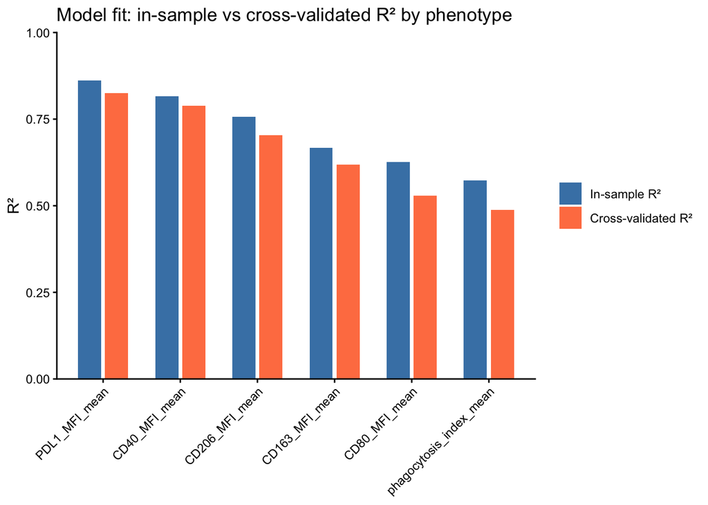

```r
results_quality %>%
  select(phenotype, r2_phenotype, cv_r2_phenotype) %>%
  pivot_longer(
    cols      = c(r2_phenotype, cv_r2_phenotype),
    names_to  = "metric",
    values_to = "r2"
  ) %>%
  mutate(
    metric   = recode(metric,
                      r2_phenotype    = "In-sample R²",
                      cv_r2_phenotype = "Cross-validated R²"),
    metric   = factor(metric, levels = c("In-sample R²", "Cross-validated R²")),
    phenotype = fct_reorder(phenotype, r2, .fun = max, .desc = TRUE)
  ) %>%
  ggplot(aes(x = phenotype, y = r2, fill = metric)) +
  geom_col(position = position_dodge(width = 0.7), width = 0.6) +
  scale_fill_manual(values = c("In-sample R²" = "steelblue", "Cross-validated R²" = "coral")) +
  scale_y_continuous(limits = c(0, 1), expand = c(0, 0)) +
  theme_classic() +
  theme(
    axis.text.x  = element_text(angle = 45, hjust = 1),
    legend.title = element_blank()
  ) +
  labs(
    title = "Model fit: in-sample vs cross-validated R² by phenotype",
    x     = NULL,
    y     = "R²"
  )
```

# Step 8 - Plot observed vs. predicted

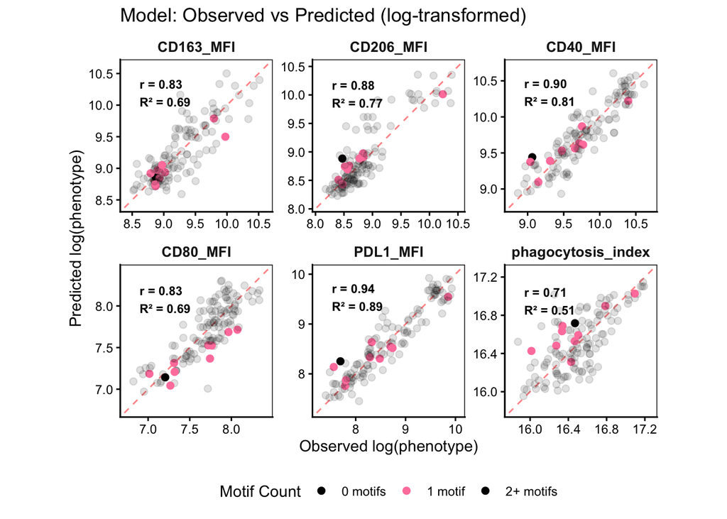

```r
# ==============================================================================
# Observed vs Predicted plots for each phenotype
# ==============================================================================

# Color/alpha scheme:
motif_colors <- c("0 motifs" = "black", "1 motif" = "palevioletred1", "2+ motifs" = "black")
motif_alphas <- c("0 motifs" = 1, "1 motif" = 1, "2+ motifs" = 0.12)

# Log transform predicted phenotype values
# ==============================================================================
log_phenotype_predictions <- results_pred %>%
  mutate(
    phenotype_label = str_remove(phenotype, "_mean$"),
    motif_group = factor(motif_group, levels = c("0 motifs", "1 motif", "2+ motifs")),
    # Log-transform phenotype (natural log)
    observed_phenotype_log = log(observed_phenotype),
    predicted_phenotype_log = log(predicted_phenotype)
  )

# Compute r and R² in log space
# ==============================================================================
log_phenotype_annotations <- log_phenotype_predictions %>%
  group_by(phenotype, phenotype_label) %>%
  summarise(
    r = suppressWarnings(cor(observed_phenotype_log, predicted_phenotype_log, use = "complete.obs", method = "pearson")),
    r2 = r^2,
    x_pos = min(observed_phenotype_log, na.rm = TRUE) +
      0.05 * (max(observed_phenotype_log, na.rm = TRUE) - min(observed_phenotype_log, na.rm = TRUE)),
    y_pos = max(predicted_phenotype_log, na.rm = TRUE) -
      0.05 * (max(predicted_phenotype_log, na.rm = TRUE) - min(predicted_phenotype_log, na.rm = TRUE)),
    .groups = "drop"
  ) %>%
  mutate(
    label = ifelse(is.finite(r),
                   sprintf("r = %.2f\nR² = %.2f", r, r2),
                   "r = NA\nR² = NA")
  )


# Get matched x/y limits per phenotype (for plotting)
# ==============================================================================
facet_limits <- log_phenotype_predictions %>%
  group_by(phenotype_label) %>%
  summarise(
    min_lim = min(c(observed_phenotype_log, predicted_phenotype_log), na.rm = TRUE),
    max_lim = max(c(observed_phenotype_log, predicted_phenotype_log), na.rm = TRUE),
    .groups = "drop"
  ) %>%
  mutate(
    pad = 0.05 * (max_lim - min_lim),
    min_lim = min_lim - pad,
    max_lim = max_lim + pad
  )
x_scales <- lapply(seq_len(nrow(facet_limits)), function(i) {
  scale_x_continuous(limits = c(facet_limits$min_lim[i], facet_limits$max_lim[i]))
})
y_scales <- lapply(seq_len(nrow(facet_limits)), function(i) {
  scale_y_continuous(limits = c(facet_limits$min_lim[i], facet_limits$max_lim[i]))
})

# Plot observed vs. predicted
# ==============================================================================
p_phenotype_log_obs_pred <- ggplot(
  log_phenotype_predictions,
  aes(x = observed_phenotype_log, y = predicted_phenotype_log,
      color = motif_group, alpha = motif_group)
) +
  geom_abline(slope = 1, intercept = 0,
              linetype = "dashed",
              color = "red",
              alpha = 0.5,
              linewidth = 0.5) +
  geom_point(size = 2) +
  geom_text(
    data = log_phenotype_annotations,
    aes(x = x_pos, y = y_pos, label = label),
    inherit.aes = FALSE,
    hjust = 0,
    vjust = 1,
    size = 3,
    fontface = "bold",
    color = "black"
  ) +
  facet_wrap(~ phenotype_label, scales = "free") +
  facetted_pos_scales(
    x = x_scales,
    y = y_scales
  ) +
  scale_color_manual(values = motif_colors, name = "Motif Count") +
  scale_alpha_manual(values = motif_alphas, guide = "none") +
  labs(
    x = "Observed log(phenotype)",
    y = "Predicted log(phenotype)",
    title = "Model: Observed vs Predicted (log-transformed)",
  ) +
  theme_classic(base_size = 11) +
  theme(
      aspect.ratio = 1,
    strip.text = element_text(face = "bold", size = 10),
    strip.background = element_blank(),
    legend.position = "bottom",
    panel.border = element_rect(color = "black", fill = NA, linewidth = 0.5)
  )

p_phenotype_log_obs_pred
```

```r
ggsave(
  filename = file.path(plot_folder, "obs_vs_pred_log_phenotype.svg"),
  plot = p_phenotype_log_obs_pred,
  width = 8,
  height = 6,
  device = "svg"
)
```

# Step 9 - Plot K values

The equilibrium constant K relates to ΔE by $K = e^{-\Delta E}$. We can convert the fitted ΔE values to K values to visualize the multiplicative effect of each motif on the equilibrium between positive and negative states.

- K > 1: Positive state is favored (corresponds to ΔE < 0)
- K = 1: States are equally populated (corresponds to ΔE = 0)
- K < 1: Negative state is favored (corresponds to ΔE > 0)

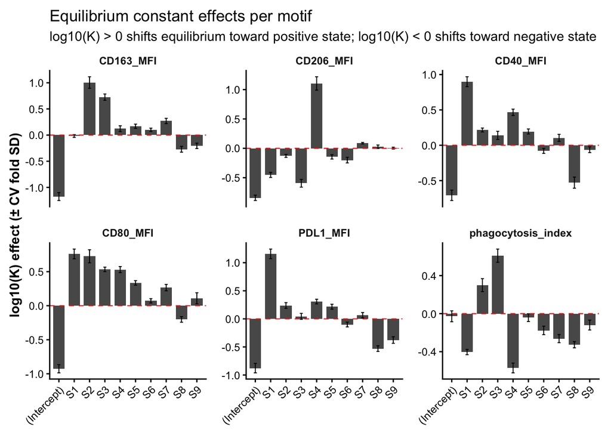

```r
# ==============================================================================
# Plot motif effects as log10(K) with CV-derived uncertainty (phenotype ΔE model)
# ==============================================================================
# Context:
#   For each surface marker, we fit a linear model in ΔE space:
#     ΔE_total = ΔE0 + Σ ΔE_Si * n_Si
#
#   Then we converted ΔE motif coefficients into equilibrium-constant effects:
#     K = exp(-ΔE)
#
#   Taking log10 gives:
#     log10(K) = log10(exp(-ΔE)) = -ΔE * log10(e)
#
# Key properties:
#   - log10(K) is a linear transform of ΔE (scaling + sign flip)
#   - therefore uncertainty propagation symmetric:
#       SD[log10(K)] = log10(e) * SD[ΔE]
#
# What the error bars represent:
#   - std.dev in results_coef is SD of coefficient estimates across CV folds
#     (coefficient stability across different training subsets).
#   - This is a CV fold-to-fold variability measure.
# ==============================================================================


# results_coef contains one row per (phenotype, term) with columns:
#   term      - coefficient name: "(Intercept)" or "S1"..."S9"
#   estimate  - fitted ΔE coefficient from the all-data linear model
#   std.dev   - SD of that coefficient across the k CV fold models
#               (measures stability: large SD = coefficient varies a lot fold-to-fold)

# Fix x-axis order: intercept first, then motifs S1-S9
term_order <- c("(Intercept)", paste0("S", 1:9))

# log10(e) ≈ 0.4343 — scaling factor used to convert ΔE units to log10(K) units
log10e <- log10(exp(1))

log10K_plot_df <- results_coef %>%
  mutate(
    # Fix term factor levels so x-axis always reads (Intercept), S1, S2, ..., S9
    term = factor(term, levels = term_order),

    # Strip "_mean" suffix for cleaner facet labels
    phenotype_label = str_remove(phenotype, "_mean$"),

    # ---- Convert ΔE coefficient -> log10(K) effect ----
    # The two-state model gives: K = exp(-ΔE)
    # Taking log10:  log10(K) = -ΔE * log10(e)
    # A positive log10(K) means the motif shifts equilibrium toward the high state.
    # A negative log10(K) means the motif shifts equilibrium toward the low state.
    log10K_estimate = -estimate * log10e,

    # ---- Propagate CV-fold SD from ΔE space to log10(K) space ----
    # std.dev is the SD of the ΔE coefficient across the k CV fold models.
    # Since log10(K) = -ΔE * log10(e) is a linear transform (Y = aX),
    # SD propagates as: SD(Y) = |a| * SD(X)
    # Here |a| = log10(e), so: SD(log10K) = log10(e) * SD(ΔE)
    # This is NOT a classical SE — it reflects fold-to-fold coefficient variability.
    log10K_sd = std.dev * log10e,

    # Error bar bounds: center ± 1 CV-fold SD in log10(K) units
    ymin = log10K_estimate - log10K_sd,
    ymax = log10K_estimate + log10K_sd
  )

# ---- Plot ----
# Each bar = log10(K) effect of one motif (or intercept) on one phenotype
# Error bars = ± 1 SD across CV folds (coefficient stability)
# Red dashed line at 0 = K of 1, meaning no shift in equilibrium
p_log10K <- ggplot(log10K_plot_df, aes(x = term, y = log10K_estimate)) +
  geom_col(width = 0.75) +
  geom_errorbar(
    aes(ymin = ymin, ymax = ymax),
    width = 0.20,
    linewidth = 0.35,
    na.rm = TRUE        # silently skip terms with NA std.dev (e.g. dropped by lm)
  ) +
  geom_hline(yintercept = 0, linewidth = 0.4, linetype = "dashed", color = "red") +
  facet_wrap(~ phenotype_label, scales = "free_y") +
  labs(
    x = NULL,
    y = "log10(K) effect (± CV fold SD)",
    title = "Equilibrium constant effects per motif",
    subtitle = "log10(K) > 0 shifts equilibrium toward positive state; log10(K) < 0 shifts toward negative state"
  ) +
  coord_cartesian(clip = "off") +
  theme_classic(base_size = 11) +
  theme(
    strip.background = element_blank(),
    strip.text = element_text(face = "bold"),
    axis.text.x = element_text(angle = 45, hjust = 1, vjust = 1),
    axis.title.y = element_text(face = "bold"),
    panel.spacing = unit(0.9, "lines"),
    plot.margin = margin(8, 10, 8, 8)
  )

p_log10K
```

```r
ggsave(
  filename = file.path(plot_folder, "motif_log10K_effects.svg"),
  plot = p_log10K,
  height = 5,
  width = 8,
  device = "svg"
)
```